# ChemHairData Exploration

Shuyao Wang

2021-09-06

# 1. Read the dataset.

```
##   ID Duplicate     Study Ancestry Treated_micro Treated_survey Perceived_color
## 1  1         0 Cambridge        1             0              0        1. Black
## 2  2         0 Cambridge        1             0              0        1. Black
## 3  3         0 Cambridge        1             0              0        1. Black
## 4  4         0 Cambridge        1             0              0        1. Black
## 5  5         0 Cambridge        6             0              0        1. Black
## 6  6         0 Cambridge        1             0              0        1. Black
##    A500  A650 PTCA TTCA H_4AHP A650_A500 TTCA_PTCA H_4AHP_PTCA PTCA_A500
## 1 0.310 0.104  346   NA    9.0 0.3354839        NA  0.02601156  1116.129
## 2 0.191 0.059  194   NA    7.5 0.3089005        NA  0.03865979  1015.707
## 3 0.255 0.082  280   NA    9.7 0.3215686        NA  0.03464286  1098.039
## 4 0.262 0.085  333   NA    7.5 0.3244275        NA  0.02252252  1270.992
## 5 0.112 0.035  141   NA    4.5 0.3125000        NA  0.03191489  1258.929
## 6 0.209 0.067  250   NA    6.7 0.3205742        NA  0.02680000  1196.172
```

# 2.Review the dataset.

### For column I to P:

- Only continuous quantitative variables.
- Represent the various proxy measures of melanins,
- I would like to make them into the response variable.
- There are five different type of the chemical elements which includes H to L, and from M to P, they are the combination of elements from H to L. Thus, I decide to find the relationship for the the variables from H to L first.

### For column A:

- Discrete quantitative variables
- Represent different tested sample.
- But they are disordered which seems to be shown in random ways.
- I guess they are just some examples which are picked through a large sample size.

### For column D:

- Discrete quantitative variables
- Represent the number of ancestories each sample has.
- But it is surprised to see it include zero value in the column.
- I guess maybe there is no record in the data.

### For column B, E, F:

- Categorical variables.
- Only include 0 and 1 which represent yes or no
- They are Duplicate, Treated_mirco, Treated_survey

### For column C:

- Categorical variable which represent type of education samples had.

```
## [1] "Cambridge" "ADAPT"     "FEMMES"
```

- We can see that there are three types included in this variables.

### For column G:

```
## [1] "1. Black"        "2. Dark Brown"   "3. Medium Brown" "4. Light Brown"
## [5] "5. Blond"        "6. Red"          "7. Grey"
```

- We can see that there are seven types included in this variables.

### For column K and N:

- They are quantitative variables.
- However, it includes many values of NA.
- The other values in these two columns are much larger than zero.
- That’s I plan to either giving up these two columns or using the average of the other value instead.
- Then I am going to check for the variance of the other value to see whether we could use the average instead.

```
## [1] 594.8536
```

```
## [1] 1.08309
```

- We get a variance of 594.8536 for TTCA and 1.08309 for TTCA_PTCA.
- I think it is not fine to use the values.

# 3. explore the data.

### I. First, I would like to see the chemical elements response to the

### different perceived colors.

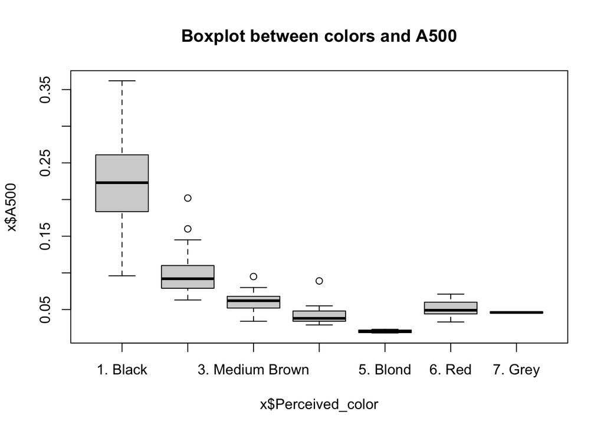

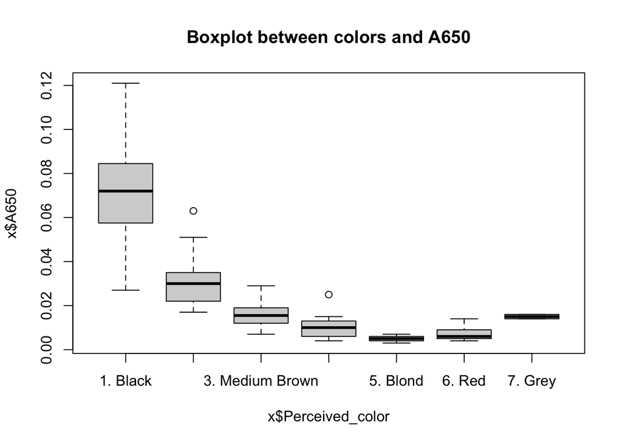

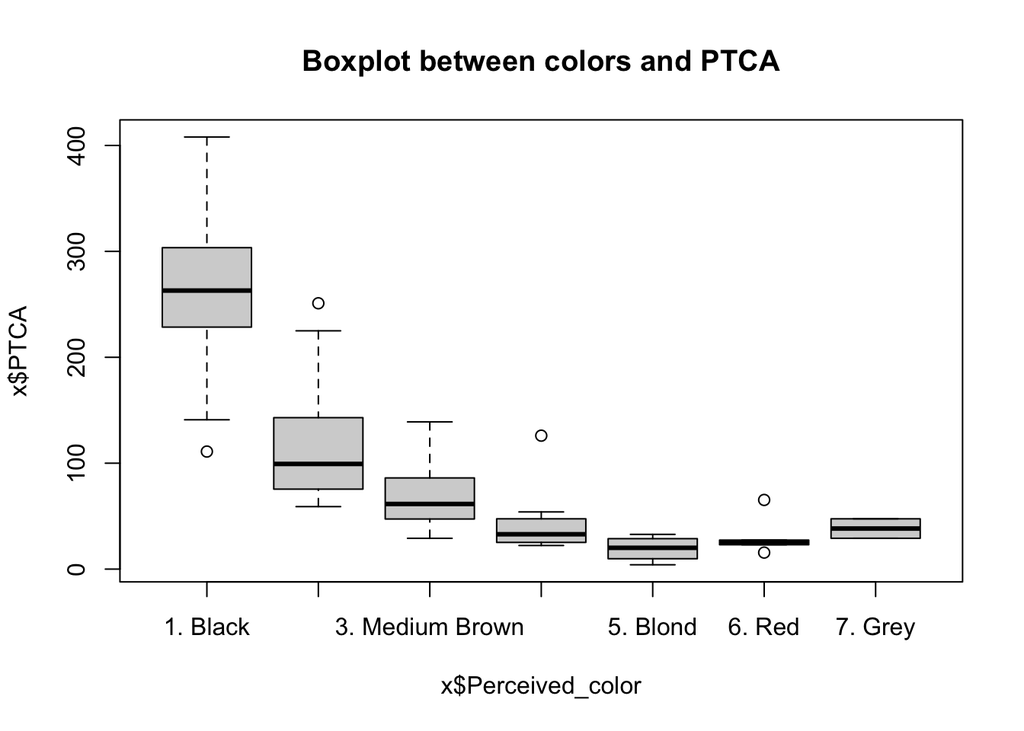

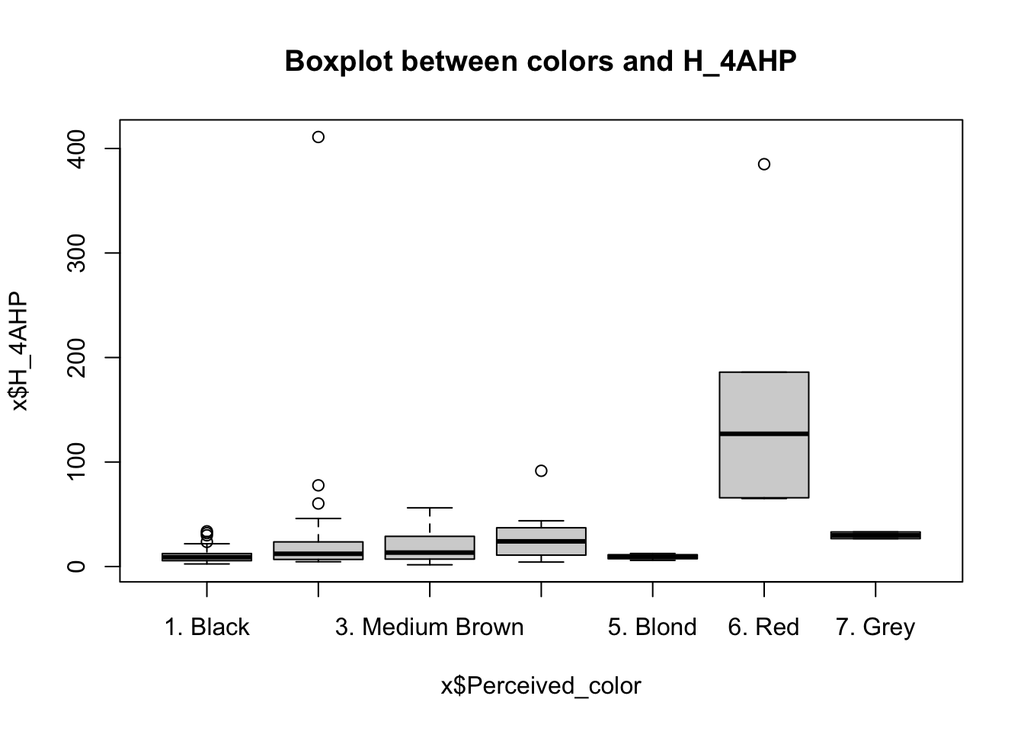

### It is surprise to see the first three graph have similar trends which

### show that Black color seems to have outstanding highest A500, A650,

### PTCA. However, the difference is not very big especially for the first

### two graphs since the scales are small. However, red color tends to

### have more H_4AHP. But all the others has pretty small value of H_4AHP.

### The difference seems to be big.

### II. Next, I would like to check for the influence on ancestry.

### Firstly, I see some zero value in the column which I would like to remove

### since they’re meaningless.

### Then I make plots to see the influence.

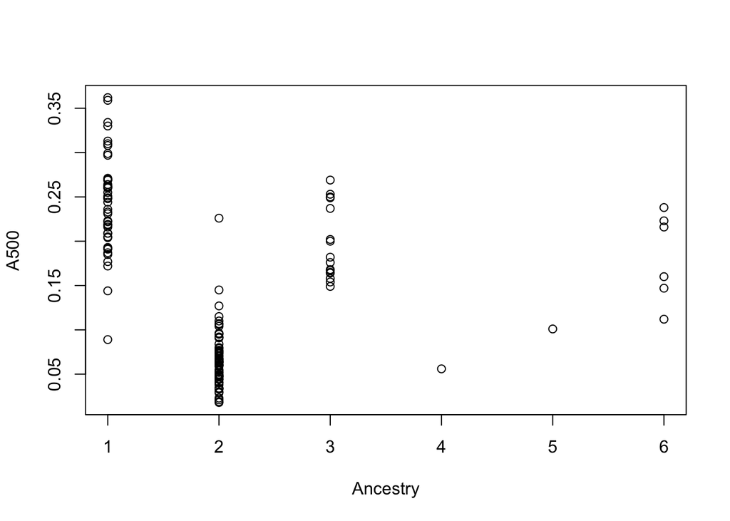

### I don’t see a outstanding pattern relationship between chemicals and

### ancestry. Thus, I would like to put them into boxplot.

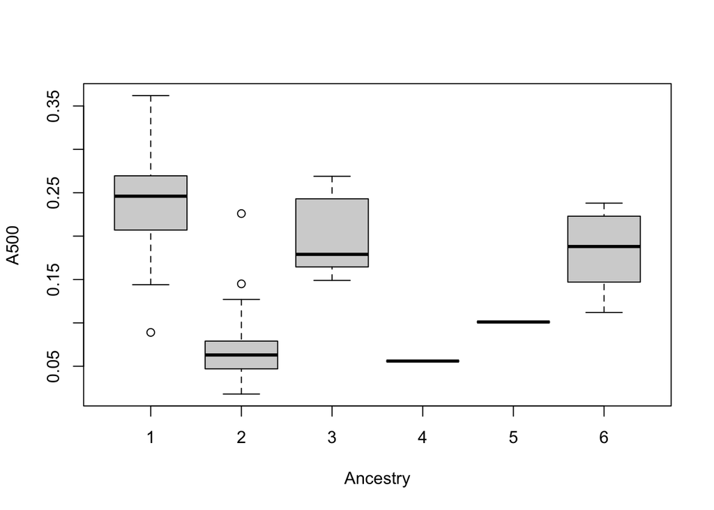

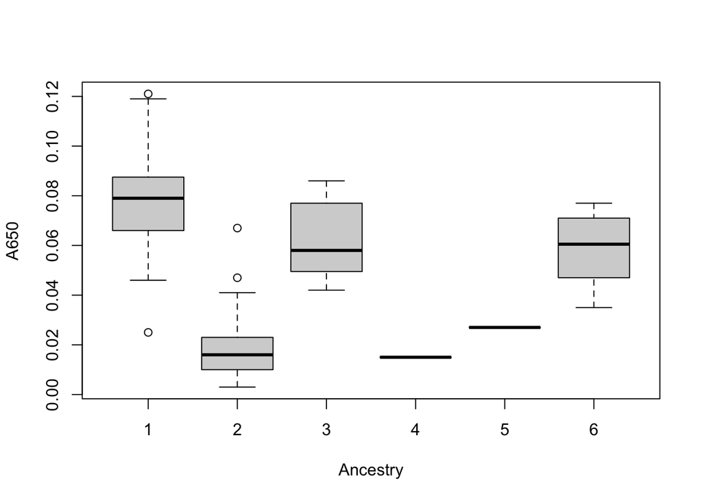

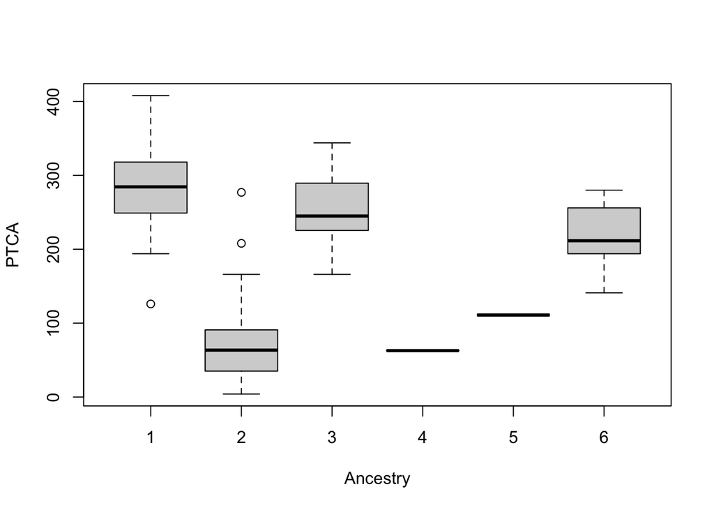

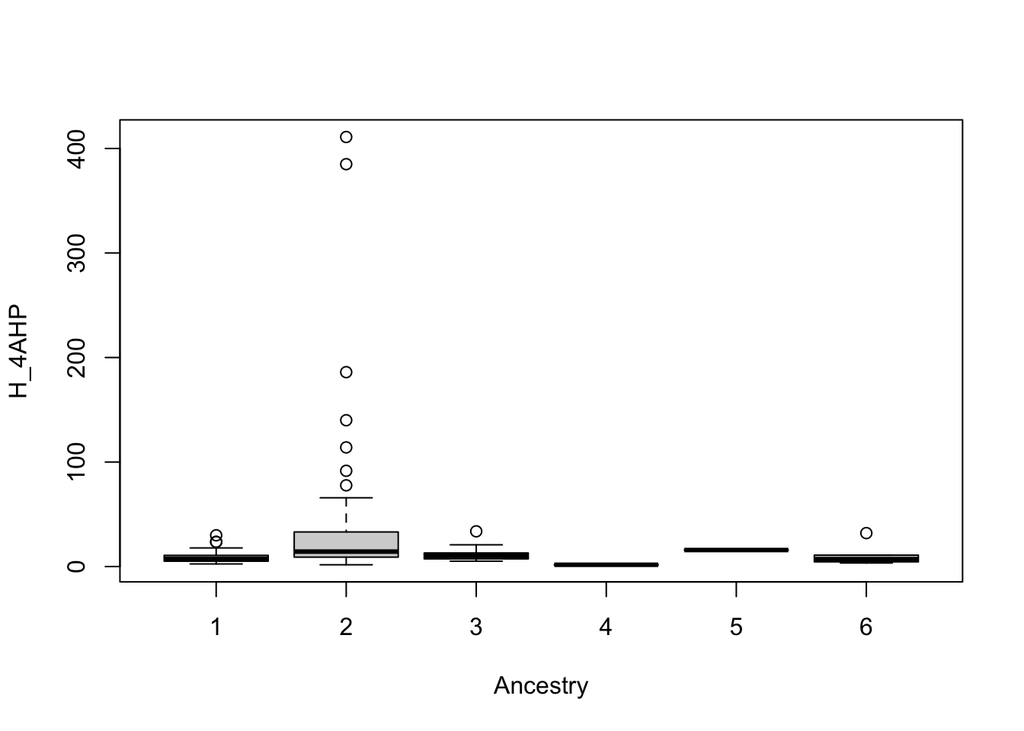

### From the graph of A500, A650, PTCA, we can see that they show that most

### dots fall between 1 and 2 since the range of them are the largest. And

### for the ancestry of 1,3,6, they tend to have bigger value of chemicals.

### However, for the graph of H_4AHP, it is salient to see that the mode of

### the data falls on 2. It is also happy to see that the highest value and

### medium also falls onto it.

### III. let’s further explore whether there are some relationship between

### chemicals.

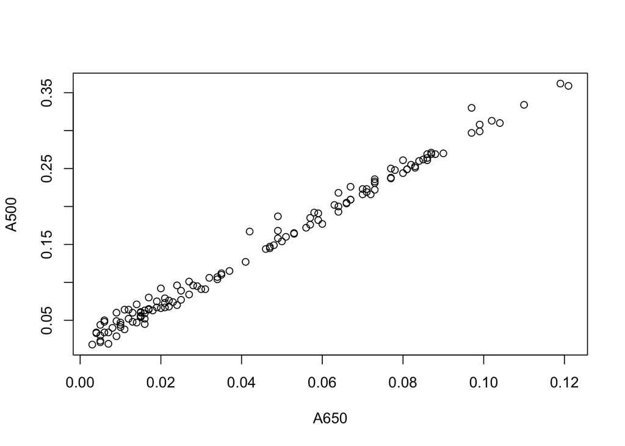

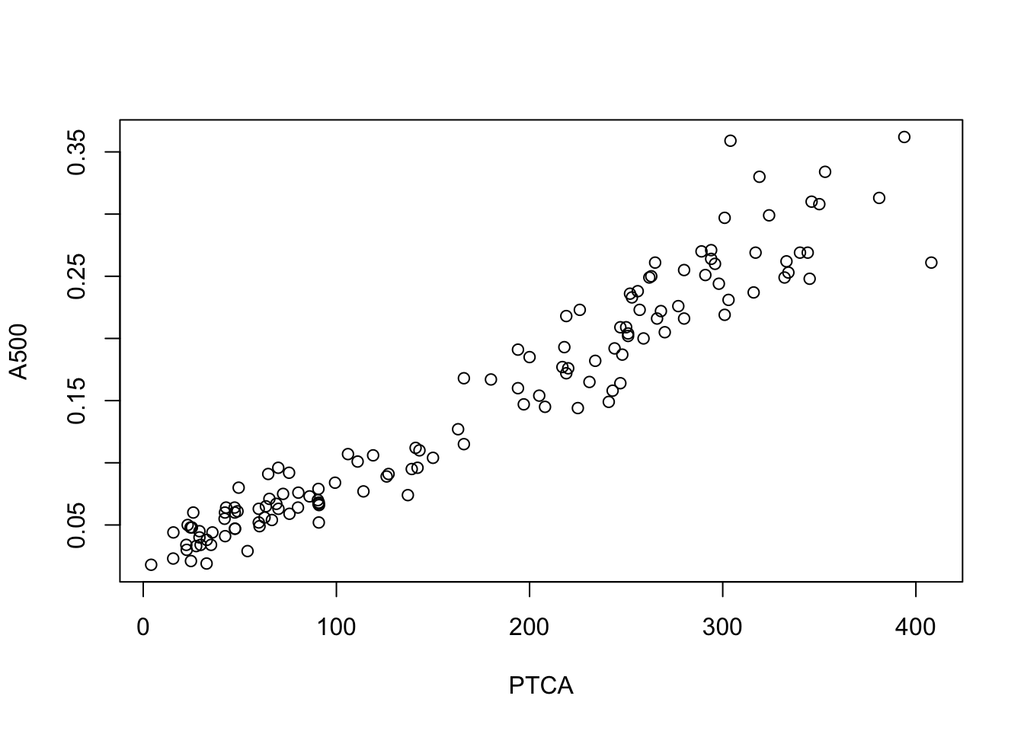

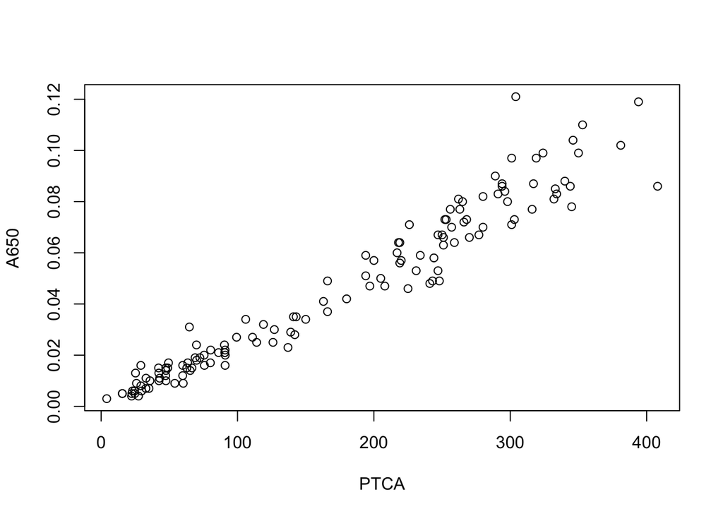

### We can see that those three graphs display a clear positive linear

### relationship. Thus, I expect to see a simple linear regression model for

### it. Thus, I put them into the format.

```
##
## Call:
## lm(formula = A500 ~ A650, data = x)
##
## Residuals:
##       Min        1Q    Median        3Q       Max
## -0.016458 -0.005606 -0.001925  0.003501  0.032437
##
## Coefficients:
##             Estimate Std. Error t value Pr(>|t|)
## (Intercept) 0.014820   0.001362   10.88   <2e-16 ***
## A650        2.914876   0.024791  117.58   <2e-16 ***
## ---
## Signif. codes:  0 '***' 0.001 '**' 0.01 '*' 0.05 '.' 0.1 ' ' 1
##
## Residual standard error: 0.008984 on 131 degrees of freedom
## Multiple R-squared:  0.9906, Adjusted R-squared:  0.9905
## F-statistic: 1.382e+04 on 1 and 131 DF,  p-value: < 2.2e-16
```

```
##
## Call:
## lm(formula = A500 ~ PTCA, data = x)
##
## Residuals:
##       Min        1Q    Median        3Q       Max
## -0.073845 -0.014979 -0.001507  0.015623  0.106760
##
## Coefficients:
##              Estimate Std. Error t value Pr(>|t|)
## (Intercept) 1.078e-02  3.831e-03   2.814  0.00565 **
## PTCA        7.943e-04  1.879e-05  42.266  < 2e-16 ***
## ---
## Signif. codes:  0 '***' 0.001 '**' 0.01 '*' 0.05 '.' 0.1 ' ' 1
##
## Residual standard error: 0.02424 on 131 degrees of freedom
## Multiple R-squared:  0.9317, Adjusted R-squared:  0.9312
## F-statistic:  1786 on 1 and 131 DF,  p-value: < 2.2e-16
```

```
##
## Call:
## lm(formula = A650 ~ PTCA, data = x)
##
## Residuals:
##       Min        1Q    Median        3Q       Max
## -0.023793 -0.004327  0.000182  0.003472  0.039547
##
## Coefficients:
##               Estimate Std. Error t value Pr(>|t|)
## (Intercept) -1.388e-03  1.220e-03  -1.138    0.257
## PTCA         2.725e-04  5.983e-06  45.543   <2e-16 ***
## ---
## Signif. codes:  0 '***' 0.001 '**' 0.01 '*' 0.05 '.' 0.1 ' ' 1
##
## Residual standard error: 0.007717 on 131 degrees of freedom
## Multiple R-squared:  0.9406, Adjusted R-squared:  0.9401
## F-statistic:  2074 on 1 and 131 DF,  p-value: < 2.2e-16
```

### Let’s see the confidence interval.

```
##                  2.5 %     97.5 %
## (Intercept) 0.01212621 0.01751386
## A650        2.86583262 2.96391879
```

```
##                    2.5 %       97.5 %
## (Intercept) 0.0032014187 0.0183571045
## PTCA        0.0007571028 0.0008314545
```

```
##                     2.5 %       97.5 %
## (Intercept) -0.0038011631 0.0010243396
## PTCA         0.0002606674 0.0002843407
```

### And from the confidence interval of three models, we don’t see the value

### of zero for model 1 and 2 which also indicates that there is a

### relationship. However, for the model 3, the result is not very ideal.

### Let’s further check for the correlation test.

```
##
##  Pearson's product-moment correlation
##
## data:  x$A650 and x$A500
## t = 117.58, df = 131, p-value < 2.2e-16
## alternative hypothesis: true correlation is not equal to 0
## 95 percent confidence interval:
##  0.9933715 0.9966618
## sample estimates:
##       cor
## 0.9952954
```

```
##
##  Pearson's product-moment correlation
##
## data:  x$PTCA and x$A500
## t = 42.266, df = 131, p-value < 2.2e-16
## alternative hypothesis: true correlation is not equal to 0
## 95 percent confidence interval:
##  0.9513183 0.9752239
## sample estimates:
##       cor
## 0.9652351
```

```
##
##  Pearson's product-moment correlation
##
## data:  x$PTCA and x$A650
## t = 45.543, df = 131, p-value < 2.2e-16
## alternative hypothesis: true correlation is not equal to 0
## 95 percent confidence interval:
##  0.9577306 0.9785220
## sample estimates:
##       cor
## 0.9698426
```

### However, from the result, we see that all three of these p-value for the

### test are very small. And the result of the correlation is big. Thay are

### all over 0.9 which indicates a strong linear relationship.

### As a result, we can see that all of those three variables display a

### relationship between each other which indicates they have impact on each

### other. Moreover, from adjusted R^2 and correction value, we get the idea

### that A500 and A650 have the most obvious relationships between each other.

### A500 and PTCA also shows a strong linear relationship with high adjusted

# Conclusion